# Publication_Bias_Final

Sophie Tascedda

2025-05-03

# Distribution fitting and multiple simulations for Published vs In-House data

## 1. Loading and PRe-processing

### 1.1 Loading the necessary libraries and the data

```r
library(readxl)
library(ggplot2)
library(tidyverse)
library(logitnorm)
library(Cairo)
```

**Instructions:**

For variables ‘pathFDA’ and ‘pathInHouse’ substitute your own path to the data sheets.

```r
pathFDA<-'y_pub_new2.xlsx'
pathInHouse<-'Inhouse_ymax_anonym.xlsx'
y_maxFDA <- read_excel(pathFDA)
Inhouse_ymax <- read_excel(pathInHouse)
# Filtering Inhouse_ymax to keep only rows where "Flag" equals 1
Inhouse_ymax <- Inhouse_ymax %>% filter(Flag == 1)
```

### 1.2 Restructure the data

For compatibility with the rest of the notebook, both data-sheets need to be in the following form:

- 1 variable representing the ADA-positivity rate, called *‘ymax’*
- 1 variable with the respective compound name, called *‘ID’*.

The following chunk restructures my data to be in this format. If your data is already built in excel to follow the required format, this step is optional.

Otherwise, fill in the name you gave to your *ymax* and *compound* columns in the respective variables and run the chunk.

```r
#Skip if it's already 'ymax'
my_FDA_y_name<-'Conc'


#Skip if it's already 'ID'
my_FDA_comp_name<-'ID'


#Skip if it's already 'ymax'

my_InH_y_name<-'clinical_ada_percent'


#Skip if it's already 'ID' and'phase'
my_InH_comp_name<-'molecule'
my_inH_phase_name<-'latest_phase'

y_maxFDA=y_maxFDA%>%select(my_FDA_comp_name,my_FDA_y_name)%>%
  rename('ymax'=my_FDA_y_name,'ID'=my_FDA_comp_name)
y_maxInH=Inhouse_ymax%>%select(my_InH_comp_name,my_InH_y_name,my_inH_phase_name)%>%
  rename('ymax'=my_InH_y_name,'ID'=my_InH_comp_name,'phase'=my_inH_phase_name)
y_maxInH$ymax=y_maxInH$ymax/100
```

Finally, re-group data with regards to Phase:

```r
unique(y_maxInH$phase)
```

```
[1] "PHASE I"    "PHASE I/II" "PHASE IB"   "PHASE II"   "PHASE III"  "PHASE IIIB"
```

```r
y_maxInH$phase_new=y_maxInH$phase
# Reclassify 'phase_new' variable
y_maxInH=y_maxInH %>%
  mutate(phase_new = case_when(
    phase_new == "PHASE IB" ~ "PHASE I",
    phase_new == "PHASE I/II" ~ "PHASE II",
    phase_new == "PHASE IIIB" ~ "PHASE III",
    TRUE ~ phase_new
  ))
```

## 2. Visualizing the distribution of Published ADA-positivity rates for FDA approved compounds VS In-House rates.

### 2.1 Density plot (Publication Figure 1)

Just run the chunk. Don’t change/substitute anything.

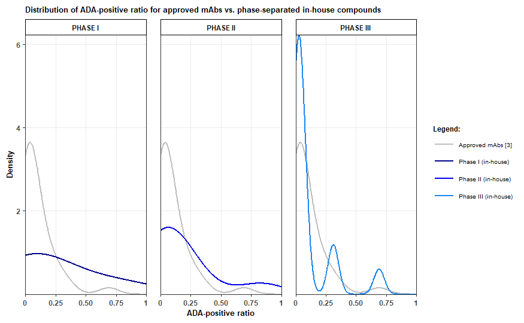

```r
format_x_axis <- function(x) {
  ifelse(x %in% c(0, 1), as.character(x), sprintf("%.2f", x))
}

gg_density <- ggplot() +
  geom_line(data = y_maxFDA, aes(x = ymax, y = ..density.., color = "FDA"),
            stat = "density", linewidth = 0.7, adjust = 2) +
  geom_line(data = y_maxInH, aes(x = ymax, y = ..density.., color = phase_new),
            stat = "density", linewidth = 0.7, adjust = 2) +
  facet_wrap(~ phase_new, nrow = 1) +
  scale_color_manual(
    values = c("PHASE I" = "darkblue",
               "PHASE II" = "blue2",
               "PHASE III" = "dodgerblue2",
               "FDA" = "grey"),
    labels = c("PHASE I" = "Phase I (in-house)",
               "PHASE II" = "Phase II (in-house)",
               "PHASE III" = "Phase III (in-house)",
               "FDA" = "Approved mAbs [3]")
  ) +
  labs(
    title = "Distribution of ADA-positive ratio for approved mAbs vs. phase-separated in-house compounds",
    x = "ADA-positive ratio",
    y = "Density",
    color = "Legend:"
  ) +
  scale_x_continuous(expand = c(0, 0), labels = format_x_axis) +
  scale_y_continuous(expand = c(0, 0)) +
  theme_bw() +
  theme(
    axis.text.x = element_text(size = 7,face = "bold"),
    axis.text.y = element_text(size = 7,face = "bold"),
    axis.title = element_text(size = 8,face = "bold"),
    plot.title = element_text(size = 8, face = "bold"),
    legend.text = element_text(size = 6),
    legend.title = element_text(size = 7, face = "bold"),
    legend.key.width = unit(0.8, "cm"),
    strip.text = element_text(size = 7, face = "bold"),
    panel.spacing = unit(1, "lines"),
    panel.grid.minor = element_blank(),
    strip.background = element_rect(color = "black", fill = "white")
  )

gg_density
```

```r
# Adjust your plot layout
gg_density_final <- gg_density +
  facet_wrap(~ phase_new, nrow = 1) +  # Force horizontal layout
  theme(
    legend.position = "right",         # Or "bottom" if you want to center it
    plot.title = element_text(hjust = 0.5)  # Center title
  )
```

```r
# Save it correctly
ggsave(
  filename = "figure1_final_rightLeg.tiff",
  plot = gg_density_final,
  width = 86*2,
  height = 86,
  units = "mm",
  dpi = 400,
  device = "tiff"    # <<<<<< just put "tiff" here
)
```

## 3. Distribution fitting: Finding the parameters of logit-normal distributions that represent the FDA and the In-House data.

### 3.1 Published data for FDA approved compounds: Estimating logit parameters from a vector of quantiles and percentiles.

**Details:**

Function *‘twCoefLogitnormN()’* from library *‘logitnorm’* allows to estimate the coefficients (mu and sigma) of the logit-normal distribution that best represents the data at hand from a vector of quantiles and percentiles. Those estimated mu and sigma are saved in a vector called ‘*theta*’. Function ‘*dlogitnorm()*’ generates a density function from the estimated *mu (theta[1])* and *sigma (theta[2])*. We do this for the support x = sequence of equally spaced (0.01) points between 0 and 1.

**Instructions:**

Here we define ‘x’ as our vector of y_max values. The ‘*twCoefLogitnormN()*’ allows to choose the quantiles we want to use for the estimation.

#### 3.1.1 Estimating mu and sigma (= estimating the logit)

```r
x_fda=y_maxFDA$ymax
thetaFDA<-twCoefLogitnormN(quant=quantile(x_fda,na.rm = TRUE,probs = c(0.1,0.25,0.5,0.75,0.9)),perc=c(0.1,0.25,0.5,0.75,0.9))
y_estFDA<- dlogitnorm(x=seq(0,1,by=0.01),mu = thetaFDA[1],sigma = thetaFDA[2])
print(thetaFDA)
```

```
       mu     sigma
-3.220187  1.935636
```

### 3.2 In-House data: Estimating logit parameters from a vector of quantiles and percentiles.

Details and instructions same as above.

#### 3.2.1 Estimating mu and sigma (= estimating the logit)

```r
x_inh=y_maxInH$ymax
thetaInH<-twCoefLogitnormN(quant=quantile(x_inh,na.rm = TRUE,probs = c(0.1,0.25,0.5,0.75,0.9)),perc=c(0.1,0.25,0.5,0.75,0.9),theta0 = c(mu = -1, sigma = 1))
y_estInH<- dlogitnorm(x=seq(0,1,by=0.01),mu = thetaInH[1],sigma = thetaInH[2])
print(thetaInH)
```

```
       mu     sigma
-2.920935  2.705731
```

By Phase

```r
estimate_logitnorm <- function(data) {
  x <- data$ymax
  theta <- twCoefLogitnormN(
    quant = quantile(x, na.rm = TRUE, probs = c(0.1, 0.25, 0.5, 0.75, 0.9)),
    perc = c(0.1, 0.25, 0.5, 0.75, 0.9),
    theta0 = c(mu = -1, sigma = 1)
  )

  # Create estimated density values
  y_est <- dlogitnorm(x = seq(0, 1, by = 0.01), mu = theta[1], sigma = theta[2])

  # Return results as a list
  list(
    mu = theta[1],
    sigma = theta[2],
    y_est = y_est
  )
}

# Apply the function phase-wise using dplyr
thetaInH_phase <- y_maxInH %>%
  group_by(phase_new) %>%
  summarise(
    mu = estimate_logitnorm(cur_data())$mu,
    sigma = estimate_logitnorm(cur_data())$sigma,
    y_est = list(estimate_logitnorm(cur_data())$y_est),
    .groups = "drop"
  )

# Print the results
print(thetaInH_phase)
```

| phase_new | mu | sigma | y_est |
| --- | --- | --- | --- |
| PHASE I | -2.815722 | 3.729976 |  |
| PHASE II | -3.129250 | 2.428750 |  |
| PHASE III | -3.373458 | 1.854233 |  |

## 4. Simulating profiles

### 4.1 Published data for FDA-approved compounds

#### 4.1.1 Generating the simulated ymax values

**Details:**

The first step is to generate the simulated values for parameter *ymax*. This is the only parameter that is not taken from the monkeys. To do this, we use function ‘*rlogitnorm()*’ which allows random number generation for logit-normal distribution. In particular, we use the logit-normal that is generated with the mu and sigma values estimated from the FDA data.

We do this for n=10000, meaning we simulate 10000 subjects (Compounds). We then save this in a data-frame (*df*) in which we will save the simulated values for all the model parameters.

**Instructions:**

Here we have the freedom to change the number of subjects we want to simulate. To do this, change the value of variable ‘*my_n*’

```r
set.seed(123)
my_n=10000

y_sim_fda<-rlogitnorm(n=my_n,mu=thetaFDA[1],sigma = thetaFDA[2])
df_fda=data.frame(y_sim=y_sim_fda)
df_fda$ind<-seq.int(nrow(df_fda))
```

#### 4.1.2 Generating the simulated values for other parameters,which come from the fitting on the monkey data.

**t_lag**

*log-normal* distribution with:

- mu=log(13.76)=2.621766, and
- sigma=1.44

```r
tlag_pop=2.621766
w_tlag=1.44

df_fda$tlag_sim<-rlnorm(n=my_n,meanlog = tlag_pop,sdlog = w_tlag)
```

**k_np**

*log-normal* distribution with:

```r
knp_pop=-0.1508229
w_knp=1.44

df_fda$knp_sim<-rlnorm(n=my_n,meanlog = knp_pop,sdlog = w_knp)
```

**b**

*logit-normal* distribution with:

```r
b_pop=-8.568296
w_b=5

df_fda$b_sim=rlogitnorm(n=my_n,mu=b_pop,sigma = w_b)
```

#### 4.1.3 Generate a profile for each line

**Details:**

The following function *‘mod’* defines the model we are using to simulate profiles, which coincides with ’*model 3*’from the work done with the studies on monkeys. The model equation is the following:

$$y = y_{max} - (y_{max} -
b)*\exp\left(-\frac{k_{np}}{y_{max}}*(t-t_{lag})\right)$$

```r
mod=function(t){
  if (t<tlag) {
   y=b}
  else{
    y=ymax-(ymax-b)*exp(-(knp/ymax)*(t-tlag))
  }
}
```

**Details:**

The following *for-loop* generates the ‘*simulated data-frame*’.

For each subject i, the value of *mod()* is computed for time-points equally distributed between 0 and tmax.

The data-frame we need for the visualization is called tmp2. For this, we calculate the following for each time-point across simulations:

- median
- value at quantile 0.1 and 1-0.1=0.9
- value at quantile 0.2 and 1-0.2=0.8
- value at quantile 0.3 and 1-0.3=0.7
- value at quantile 0.4 and 1-0.4=0.6

**Instructions:**

The number of time-points and the step-size can be set by changing the value of variables ‘*tmax*’and’*step*’, respectively.

Here the choice was for Q1=0.1, Q2=0.2, Q3=0.3 and Q4=0.4. Those values can be changed by changing the respective variable values.

```r
dflist=list()

tmax=100
step=1

Q1=0.1
Q2=0.2
Q3=0.3
Q4=0.4
```

```r
i=1
for (i in 1:my_n){
  ymax=df_fda$y_sim[i]
  tlag=df_fda$tlag_sim[i]
  b=df_fda$b_sim[i]
  knp=df_fda$knp_sim[i]
  d=data.frame(y=numeric(),t=integer())
  t=0
  test=for(t in seq(0,tmax,by=step)){
  y=mod(t)
  d[t+1,]<-c(y,t)
  t=t+1
  }
  d$ind=i
  dflist[[i]]=d
  i=i+1
}
```

```r
df_sim_fda=do.call(rbind,dflist)

df_sim_fda%>%group_by(t)%>%summarise(avg=median(y),q1=quantile(y,probs=Q1),q1bis=quantile(y,probs=(1-Q1)),q2=quantile(y,probs=Q2),q2bis=quantile(y,probs=(1-Q2)),q3=quantile(y,probs=Q3),q3bis=quantile(y,probs=(1-Q3)),q4=quantile(y,probs=Q4),q4bis=quantile(y,probs=(1-Q4)))->tmp2
```

### 4.2 In-House data

#### 4.1.1 Generating the simulated ymax values and appending columns with the generated values for the other parameters

**Instructions:**

The number of simulated subjects is again controllable with ‘my_n2’.

For coherence, it’s set to be equal to the one used for FDA data. For this, we can directly build the data-frame without again generating simulated values for parameters tlag, knp and b.

```r
my_n2=10000

y_sim_inh<-rlogitnorm(n=my_n2,mu=thetaInH[1],sigma = thetaInH[2])
df_inh=data.frame(y_sim=y_sim_inh)
df_inh$ind<-seq.int(nrow(df_inh))
head(df_inh)
```

|  | y_sim | ind |
| --- | --- | --- |
| 1 | 0.16584775 | 1 |
| 2 | 0.27505668 | 2 |
| 3 | 0.01345465 | 3 |
| 4 | 0.04327174 | 4 |
| 5 | 0.64617200 | 5 |
| 6 | 0.02895843 | 6 |

```r
df_inh$tlag_sim=df_fda$tlag_sim
df_inh$b_sim=df_fda$b_sim
df_inh$knp_sim=df_fda$knp_sim
```

#### 4.2.2 Generate a profile for each line

**Instructions:**

Same as for FDA data.

```r
dflist2=list()

tmax2=100
step2=1

Q1=0.1
Q2=0.2
Q3=0.3
Q4=0.4
```

```r
i=1
for (i in 1:my_n2){
  ymax=df_inh$y_sim[i]
  tlag=df_inh$tlag_sim[i]
  b=df_inh$b_sim[i]
  knp=df_inh$knp_sim[i]
  d=data.frame(y=numeric(),t=integer())
  t=0
  test=for(t in seq(0,tmax2,by=step2)){
  y=mod(t)
  d[t+1,]<-c(y,t)
  t=t+1
  }
  d$ind=i
  dflist2[[i]]=d
  i=i+1
}
```

```r
df_sim_inh=do.call(rbind,dflist2)

df_sim_inh%>%group_by(t)%>%summarise(avg=median(y),q1=quantile(y,probs=Q1),q1bis=quantile(y,probs=(1-Q1)),q2=quantile(y,probs=Q2),q2bis=quantile(y,probs=(1-Q2)),q3=quantile(y,probs=Q3),q3bis=quantile(y,probs=(1-Q3)),q4=quantile(y,probs=Q4),q4bis=quantile(y,probs=(1-Q4)))->tmp3
```

### 4.2 In-House data by phase

```r
# Number of subjects per phase
my_n2 <- 10000

# Simulate phase-wise `ymax` and reuse `tlag_sim`, `b_sim`, and `knp_sim`
simulated_phase_data <- thetaInH_phase %>%
  rowwise() %>%
  mutate(
    simulated_data = list({
      # Generate random ymax values for the phase
      y_sim_inh_ph <- rlogitnorm(n = my_n2, mu = mu, sigma = sigma)

      # Create a data frame for the phase
      df_phase <- data.frame(
        y_sim = y_sim_inh_ph,
        ind = seq.int(my_n2),  # Index for individuals
        tlag_sim = df_fda$tlag_sim,  # Reuse from FDA
        b_sim = df_fda$b_sim,        # Reuse from FDA
        knp_sim = df_fda$knp_sim,    # Reuse from FDA
        phase_new = phase_new    # Add phase information
      )
      df_phase
    })
  )

# Combine all simulated data for all phases into one data frame
df_inh_ph <- do.call(rbind, simulated_phase_data$simulated_data)

# Check the structure
#head(df_inh_ph)
```

```r
# Function to generate profiles for one phase
simulate_time_phase <- function(df_phase) {
  dflist2 <- list()  # Store simulations for individuals

  for (i in 1:nrow(df_phase)) {
    ymax <- df_phase$y_sim[i]
    tlag <- df_phase$tlag_sim[i]
    b <- df_phase$b_sim[i]
    knp <- df_phase$knp_sim[i]

    d <- data.frame(y = numeric(), t = integer())  # Empty data frame for individual

    for (t in seq(0, 100, by = 1)) {  # Simulate for t = 0 to 100 with step = 1
      # Model equation
      if (t < tlag) {
        y <- b
      } else {
        y <- ymax - (ymax - b) * exp(-(knp / ymax) * (t - tlag))
      }
      d[t + 1, ] <- c(y, t)
    }

    d$ind <- i  # Add individual index
    dflist2[[i]] <- d  # Append to list
  }

  # Combine individual simulations for the phase
  df_sim2 <- do.call(rbind, dflist2)
  df_sim2$phase_new <- unique(df_phase$phase_new)  # Add phase information
  return(df_sim2)
}

# Apply the function to each phase
df_sim_inh_ph <- df_inh_ph%>%
  group_by(phase_new) %>%
  group_split() %>%
  map_dfr(~ simulate_time_phase(.))
```

```r
# Summarize phase-wise
df_sim_inh_ph_summary <- df_sim_inh_ph %>%
  group_by(phase_new, t) %>%
  summarise(
    avg = median(y),
    q1 = quantile(y, probs = 0.1),
    q1bis = quantile(y, probs = 0.9),
    q2 = quantile(y, probs = 0.2),
    q2bis = quantile(y, probs = 0.8),
    q3 = quantile(y, probs = 0.3),
    q3bis = quantile(y, probs = 0.7),
    q4 = quantile(y, probs = 0.4),
    q4bis = quantile(y, probs = 0.6),
    .groups = "drop"
  )
```

### 4.3 All together

```r
df_fda2=df_fda
df_fda2$phase_new="FDA"
df_fda2$ind=seq(1,10000)
head(df_fda2)
```

|  | y_sim | ind | tlag_sim | knp_sim | b_sim | phase_new |
| --- | --- | --- | --- | --- | --- | --- |
| 1 | 0.01332020 | 1 | 418.053877 | 0.25792403 | 7.217620e-05 | FDA |
| 2 | 0.02494728 | 2 | 10.821737 | 0.62597302 | 6.903925e-04 | FDA |
| 3 | 0.44940006 | 3 | 52.278773 | 0.04159047 | 1.287952e-05 | FDA |
| 4 | 0.04378429 | 4 | 6.071632 | 0.07788937 | 5.230386e-07 | FDA |
| 5 | 0.04880283 | 5 | 19.027698 | 0.17694976 | 1.687241e-02 | FDA |
| 6 | 0.52486812 | 6 | 70.233521 | 0.07813498 | 1.751761e-04 | FDA |

```r
df_combined=rbind(df_fda2,df_inh_ph)
```

```r
# Apply the function to each phase
df_sim_combined <- df_combined %>%
  group_by(phase_new) %>%
  group_split() %>%
  map_dfr(~ simulate_time_phase(.))
```

```r
# Summarize phase-wise
df_sim_combined_summary <- df_sim_combined %>%
  group_by(phase_new, t) %>%
  summarise(
    avg = median(y),
    q1 = quantile(y, probs = 0.1),
    q1bis = quantile(y, probs = 0.9),
    q2 = quantile(y, probs = 0.2),
    q2bis = quantile(y, probs = 0.8),
    q3 = quantile(y, probs = 0.3),
    q3bis = quantile(y, probs = 0.7),
    q4 = quantile(y, probs = 0.4),
    q4bis = quantile(y, probs = 0.6),
    .groups = "drop"
  )
```

[figure not shown]

```r
# Define custom labels for facets
facet_labels <- c(
  "PHASE I" = "IN-HOUSE PHASE I",
  "PHASE II" = "IN-HOUSE PHASE II",
  "PHASE III" = "IN-HOUSE PHASE III",
  "FDA" = "APPROVED MABS"
)

# Ensure phase_new is a factor with the correct levels
df_sim_combined_summary$phase_new <- factor(
  df_sim_combined_summary$phase_new,
  levels = c("PHASE I", "PHASE II", "PHASE III", "FDA")
)

# Updated Plot
ggtest <- ggplot(data = df_sim_combined_summary, aes(x = t)) +
  # Add ribbons for confidence intervals
  geom_ribbon(aes(ymin = q1, ymax = q1bis, fill = interaction(phase_new, "R1")), alpha = 0.1) +
  geom_ribbon(aes(ymin = q2, ymax = q2bis, fill = interaction(phase_new, "R2")), alpha = 0.3) +
  geom_ribbon(aes(ymin = q4, ymax = q4bis, fill = interaction(phase_new, "R4")), alpha = 0.8) +
  geom_line(aes(y = avg, linetype = 'Median'), linewidth = 0.5, color = 'black') +
  # Facet with custom labels
  facet_wrap(
    ~ phase_new,
    nrow = 1,
    labeller = labeller(phase_new = facet_labels)
  ) +
  # Manual fill scale for confidence intervals
  scale_fill_manual(
    values = c(
      "PHASE I.R1" = alpha('dodgerblue2', 0.2),
      "PHASE I.R2" = alpha('dodgerblue2', 0.4),
      "PHASE I.R4" = alpha('dodgerblue2', 0.8),
      "PHASE II.R1" = alpha('dodgerblue2', 0.2),
      "PHASE II.R2" = alpha('dodgerblue2', 0.4),
      "PHASE II.R4" = alpha('dodgerblue2', 0.8),
      "PHASE III.R1" = alpha('dodgerblue2', 0.2),
      "PHASE III.R2" = alpha('dodgerblue2', 0.4),
      "PHASE III.R4" = alpha('dodgerblue2', 0.8),
      "FDA.R1" = alpha('violetred', 0.2),
      "FDA.R2" = alpha('violetred', 0.4),
      "FDA.R4" = alpha('violetred', 0.8)
    ),
    breaks = c("PHASE I.R1", "PHASE I.R2", "PHASE I.R4", "FDA.R1", "FDA.R2", "FDA.R4"),
    labels = c("","","", R1_label, R2_label, R4_label)
  ) +
  scale_linetype_manual(
    name = NULL,
    values = c("Median" = "solid"),
    labels = c("Median")
  ) +
  # Add guides to group legend entries
  guides(
    fill = guide_legend(
      override.aes = list(
        alpha = c(0.2, 0.4, 0.8, 0.2, 0.4, 0.8),
        fill = c('dodgerblue2', 'dodgerblue2', 'dodgerblue2', 'violetred', 'violetred', 'violetred')
      ),
      title = "Confidence intervals (percentile ranges):",
      ncol = 2,
      title.position = "top"
    ),
    linetype = guide_legend(
      override.aes = list(color = "black", linewidth = 1),
      title = NULL
    )
  ) +
  scale_x_continuous(breaks = c(0, 50, 100), expand = c(0, 0)) +
  scale_y_continuous(expand = c(0, 0), limits = c(0, 1)) +
  ylab('ADA-positive ratio') +
  xlab('time [days]') +
  theme_bw() +
  ggtitle('Simulated ADA-Positive Ratio Over Time') +
  labs(
    subtitle = 'Confidence intervals reflect variability derived from logit-normal distributions fitted to publicly available data and in-house study data.'
  ) +
  theme(
    axis.text = element_text(size = 7,face='bold'),
    axis.title = element_text(size = 8,face='bold'),
    plot.title = element_text(size = 8, face = "bold"),
    plot.subtitle = element_text(size = 8, color = 'gray38'),
    legend.text = element_text(size = 6),
    legend.title = element_text(size = 7, face = 'bold'),
    legend.position = "bottom",
    legend.box = "horizontal",
    legend.key.size = unit(0.6, "lines"),
    strip.text = element_text(size = 7, face = "bold"),
    panel.spacing = unit(0.5, "lines"),
    panel.grid.minor = element_blank(),
    plot.margin = margin(10, 20, 10, 10),
    strip.background = element_rect(
      color = "black", fill = "white"
    )
  )

# Plot the refined visualization
ggtest
```

```r
ggsave(
  filename = "figure2_final_bottomLeg.tiff",
  plot = ggtest,
  width = 2*86,
  height = 96,  # make it taller to preserve readability
  units = "mm",
  dpi = 400,
  device = "tiff"
)
```

### Plot for appendix

```r
# Label each dataset
tmp3$source <- "In-House Overall"
fda_plot_data <- df_sim_combined_summary %>%
  filter(phase_new == "FDA") %>%
  mutate(source = "Approved mAbs")

# Match columns if needed
combined_df_app <- bind_rows(
  tmp3 %>% select(t, avg, q1, q1bis, q2, q2bis, q4, q4bis, source),
  fda_plot_data %>% select(t, avg, q1, q1bis, q2, q2bis, q4, q4bis, source)
)
```

```r
combined_df_app$source <- factor(
  combined_df_app$source,
  levels = c("In-House Overall","Approved mAbs" )  # Desired order
)
```

```r
combined_df_app$fill_r1 <- interaction(combined_df_app$source, "R1")
combined_df_app$fill_r2 <- interaction(combined_df_app$source, "R2")
combined_df_app$fill_r4 <- interaction(combined_df_app$source, "R4")
```

[figure not shown]

```r
gg_combined_app <- ggplot(data = combined_df_app, aes(x = t)) +
  geom_ribbon(aes(ymin = q1, ymax = q1bis, fill = fill_r1), alpha = 0.1) +
  geom_ribbon(aes(ymin = q2, ymax = q2bis, fill = fill_r2), alpha = 0.3) +
  geom_ribbon(aes(ymin = q4, ymax = q4bis, fill = fill_r4), alpha = 0.8) +
  geom_line(aes(y = avg, linetype = "Median"), color = "black", linewidth = 0.5) +
  facet_wrap(~ source, nrow = 1) +

  scale_fill_manual(
    values = c(
      "In-House Overall.R1" = alpha("dodgerblue2", 0.2),
      "In-House Overall.R2" = alpha("dodgerblue2", 0.4),
      "In-House Overall.R4" = alpha("dodgerblue2", 0.8),
      "Approved mAbs.R1" = alpha("violetred", 0.2),
      "Approved mAbs.R2" = alpha("violetred", 0.4),
      "Approved mAbs.R4" = alpha("violetred", 0.8)
    ),
    breaks = c("In-House Overall.R1", "In-House Overall.R2", "In-House Overall.R4",
               "Approved mAbs.R1", "Approved mAbs.R2", "Approved mAbs.R4"),
    labels = c("", "", "", R1_label, R2_label, R4_label)
  ) +

  scale_linetype_manual(
    name = NULL,
    values = c("Median" = "solid"),
    labels = c("Median")
  ) +

  guides(
    fill = guide_legend(
      override.aes = list(
        alpha = c(0.2, 0.4, 0.8, 0.2, 0.4, 0.8),
        fill = c("dodgerblue2", "dodgerblue2", "dodgerblue2",
                 "violetred", "violetred", "violetred")
      ),
      title = "Confidence intervals (percentile ranges):",
      ncol = 2,
      title.position = "top"
    ),
    linetype = guide_legend(
      override.aes = list(color = "black", linewidth = 1),
      title = NULL
    )
  ) +

  scale_x_continuous(breaks = c(0, 50, 100), expand = c(0, 0)) +
  scale_y_continuous(expand = c(0, 0), limits = c(0, 1)) +
  ylab("ADA-positive ratio") +
  xlab("Time [days]") +
  ggtitle("Simulated ADA-Positive Ratio Over Time for aggregated In-house Studies and FDA-approved compounds.") +
  labs(
    subtitle = "Confidence intervals reflect variability derived from logit-normal distributions fitted to FDA-approved and aggregated in-house studies."
  ) +
  theme_bw() +
  theme(
    axis.text = element_text(size = 7, face = "bold"),
    axis.title = element_text(size = 8, face = "bold"),
    plot.title = element_text(size = 8, face = "bold"),
    plot.subtitle = element_text(size = 8, color = "gray38"),
    legend.text = element_text(size = 6),
    legend.title = element_text(size = 7, face = "bold"),
    legend.position = "bottom",
    legend.box = "horizontal",
    legend.key.size = unit(0.6, "lines"),
    strip.text = element_text(size = 7, face = "bold"),
    panel.spacing = unit(0.5, "lines"),
    panel.grid.minor = element_blank(),
    plot.margin = margin(10, 20, 10, 10),
    strip.background = element_rect(color = "black", fill = "white")
  )

gg_combined_app
```

```r
ggsave(
  filename = "figure2_appendix.tiff",
  plot = gg_combined_app,
  width = 86*2,
  height = 96,  # make it taller to preserve readability
  units = "mm",
  dpi = 400,
  device = "tiff"
)
```

```r
# Save it correctly
ggsave(
  filename = "figure1_final_rightLeg.tiff",
  plot = gg_density_final,
  width = 86*2,
  height = 86,
  units = "mm",
  dpi = 400,
  device = "tiff"    # <<<<<< just put "tiff" here
)
```